# Homework 2

Eric Gleiter; Github: Eric-Gleiter

2/3/2020

*Note: All package checks and installations code is hidden on the html*

Question 1)

```r
    cel = c(-4.44444,-9.44444)
    cel
```

```
## [1] -4.44444 -9.44444
```

Question 2)

```r
vector = c(1,3)
for (i in 3:200)
{
  if (i%%2 == 1)
  {
    vector = c(vector,1)
  }
  else
  {
    vector = c(vector,3)
  }
}
vector
```

```
##   [1] 1 3 1 3 1 3 1 3 1 3 1 3 1 3 1 3 1 3 1 3 1 3 1 3 1 3 1 3 1 3 1 3 1 3 1 3 1
##  [38] 3 1 3 1 3 1 3 1 3 1 3 1 3 1 3 1 3 1 3 1 3 1 3 1 3 1 3 1 3 1 3 1 3 1 3 1 3
##  [75] 1 3 1 3 1 3 1 3 1 3 1 3 1 3 1 3 1 3 1 3 1 3 1 3 1 3 1 3 1 3 1 3 1 3 1 3 1
## [112] 3 1 3 1 3 1 3 1 3 1 3 1 3 1 3 1 3 1 3 1 3 1 3 1 3 1 3 1 3 1 3 1 3 1 3 1 3
## [149] 1 3 1 3 1 3 1 3 1 3 1 3 1 3 1 3 1 3 1 3 1 3 1 3 1 3 1 3 1 3 1 3 1 3 1 3 1
## [186] 3 1 3 1 3 1 3 1 3 1 3 1 3 1 3
```

Question 3)

```r
numPerfect = floor(sqrt(2001))
numPerfect
```

```
## [1] 44
```

there are 44 perfect squares between 1 and 2001

**Cars and Mileage**

Question 1)

```r
mpgcopy <- mpg
hwympg <- mpgcopy$hwy
mpgcopy <- mpgcopy[order(hwympg),]
top3 <- tail(mpgcopy,3)
top3
```

```
## # A tibble: 3 x 11
##   manufacturer model   displ  year   cyl trans   drv     cty   hwy fl    class
##   <chr>        <chr>   <dbl> <int> <int> <chr>   <chr> <int> <int> <chr> <chr>
## 1 volkswagen   new be~   1.9  1999     4 auto(l~ f        29    41 d     subcom~
## 2 volkswagen   jetta     1.9  1999     4 manual~ f        33    44 d     compact
## 3 volkswagen   new be~   1.9  1999     4 manual~ f        35    44 d     subcom~
```

The top3 three are the jetta and new beetle (auto and manual) I found this by sorting the data frame by the highway mileage and then pulling out the 3 best mileages.

Question 2)

```r
compacts <- mpgcopy$class
numCompact <- 0
for (i in 1:length(compacts))
{
  if (compacts[i] == 'compact')
  {
    numCompact <- numCompact +1
  }
}
numCompact
```

```
## [1] 47
```

There are 47 compact models in this data set

Question 3)

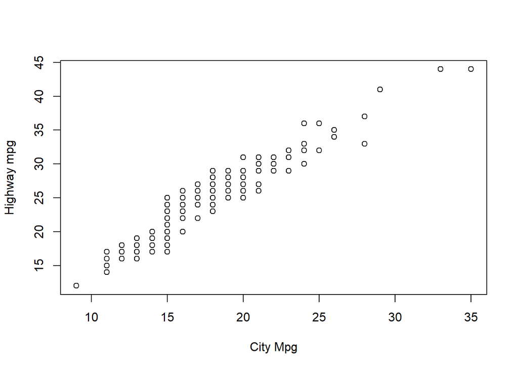

```r
plot(mpgcopy$cty, mpgcopy$hwy,ylab = "Highway mpg", xlab = "City Mpg" )
```

The reason there is only a few points showing is two fold. The first being that if two points overlap only one point would be shown, and the other being that there might be null values in one set or the other which would lead to that row being excluded in the plot. Additionally when looking at this plot I believe there is strong trend upwards suggesting that cty and hwy mpg are positively correlated.

Question 4)

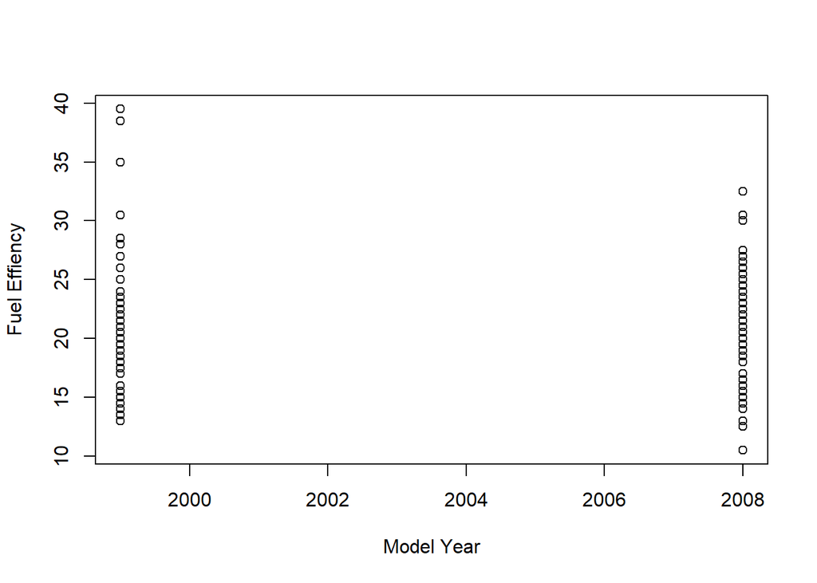

```r
mpgcopy$fuel <- (mpgcopy$cty + mpgcopy$hwy)/2
year <- mpgcopy$year
plot(year, mpgcopy$fuel, ylab = "Fuel Effiency", xlab="Model Year")
```

```r
describeBy(mpgcopy$fuel, mpgcopy$year)
```

```
##
##  Descriptive statistics by group
## group: 1999
##    vars   n  mean   sd median trimmed  mad min  max range skew kurtosis   se
## X1    1 117 20.22 5.21     21   19.81 5.19  13 39.5  26.5  0.9     1.58 0.48
## ------------------------------------------------------------
## group: 2008
##    vars   n  mean   sd median trimmed  mad  min  max range skew kurtosis   se
## X1    1 117 20.08 4.91   20.5   20.04 5.93 10.5 32.5    22 0.09    -0.66 0.45
```

First In order to compare fuel I used the average of the highway (hwy) and the city (city) fuel efficiencies. Looking at the graph we see what appears to be more cars having a higher fuel efficiency in 1999 suggested by the outliers (a box plot might have been more helpful but since I also include the descriptive statistics for each group I left it out). However, looking at the summary statistics we can see the difference in means is very small with a very similar spread this suggest that there is not significant difference in the fuel efficiency of the two types of cars a t-test would most likely confirm this hypothesis.